# Clustering_Customer_Segmentation_Project

```python
print('*'*100)
```

UNIVARAITE EDA ANALYSIS

```python
#Setting up a function to handle univariate EDA analysis using a histogram/boxplot.
def eda_analysis_hist(data,column, figsize=(12,7), kde=False, bins=None):
  #Creating the subplot.
  f2, (ax_box2, ax_hist2) = plt.subplots(nrows=2, sharex=True, figsize=figsize)

  #Creating the boxplot
  sns.boxplot(data=data, x=column, ax=ax_box2, showmeans=True, color='violet')
  #Creating the histogram with bin options
  sns.histplot(data=data, x=column, ax=ax_hist2, bins=bins, kde=kde) if bins else sns.histplot(
      data=data, x=column, ax=ax_hist2, kde=kde)

  #Showing mean value on the histogram
  ax_hist2.axvline(data[column].mean(), color='green', linestyle='--')
  ax_hist2.axvline(data[column].median(), color='black', linestyle='-')
  #Showing median on the boxplot
  ax_box2.axvline(data[column].median(), color='black', linestyle='-')

  print('0.25 quartile:',data[column].quantile(0.25),' ','median:', data[column].median(),'','0.75 quartile:', data[column].quantile(0.75))
```

```python
#Setting up a function to handle univariate EDA analysis using a countplot.
def eda_analysis_count(data,column):
  sns.countplot(data=data,x=column,order=data[column].value_counts().index)
  plt.title('Sorted')
  plt.show()
  sns.countplot(data=data,x=column)
  plt.title('Unsorted')
  plt.show()
```

```
0.25 quartile: 10000.0   median: 18000.0  0.75 quartile: 48000.0
```

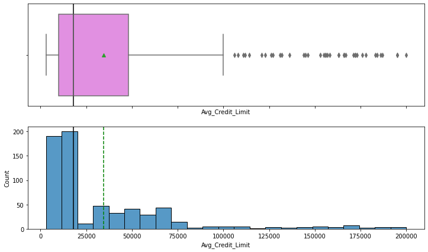

```python
#Looking at 'Avg_Credit_Limit'.
eda_analysis_hist(df,'Avg_Credit_Limit')
```

Right skewed distribution as expected as there are less wealthy people than average joes. Not sure at this time if will treat values past the max whisker of the box as outliers, probably not.

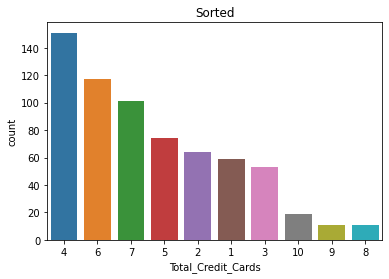

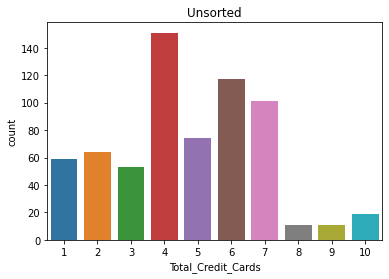

```python
#Looking at 'Total_Credit_Cards'.
eda_analysis_count(df,'Total_Credit_Cards')
```

Most customers hold a "medium" amount of cards in the range of 4-7. Some customers hold a few amount of cards in the range of 1-3. And a few customers hold a large amount fo cards in the range of 8-10.

This distribution makes sense: the upper middle class would get as many cards as they could reasonably afford (4-7). The poor or those who do not use the bank's services much would only be able to have or need 1-3 cards. And the few truly wealthy people would be able to have a high amount of cards (8-10)

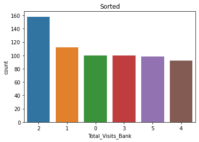

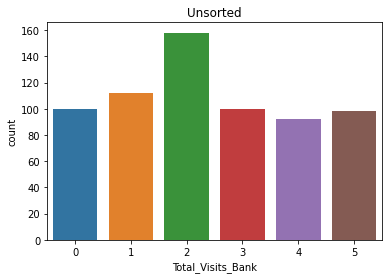

```python
#Looking at 'Total_Visits_Bank'.
eda_analysis_count(df,'Total_Visits_Bank')
```

A significant amount of customers visit the bank twice. All other customers visited the bank in equal amounts at different frequencies with only a slight trend suggesting that fewer visits were more common.

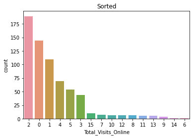

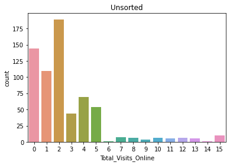

```python
#Looking at 'Total_Visits_Online'.
eda_analysis_count(df,'Total_Visits_Online')
```

Extremely right skewed. Very few customers visit the bank online more than 5 times. Open to the idea of imputing values past 5 as the median amount. However, due to the wealth distribution, in this and the following column the higher less frequent occurances correlate with the habits of wealthy people and as such would act as a good representation of them when forming clusters. So at least at first I will leave them as is.

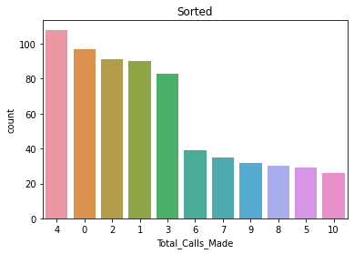

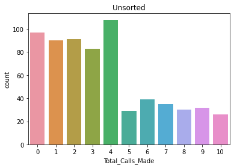

```python
#Looking at 'Total_Calls_Made'.
eda_analysis_count(df,'Total_Calls_Made')
```

Right skewed. There is a sharp decline in count after "4", with "4" having the highest count. This could indicate that customers who have not had their issue with the bank resolved by the 4th call give up and are no longer interested.

```python
print('*'*100)
```

BIVARIATE EDA ANALYSIS

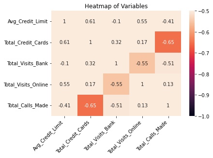

```python
#Making a heatmap of the data to understand it better.
sns.heatmap(df.corr(), annot=True, vmin=-1, vmax=-0.5)
plt.title('Heatmap of Variables')
plt.xticks(rotation=45, ha='right')
plt.show()
```

"Total_Credit_Cards" and "Avg_Credit_Limit" have the highest positive correlation with a value of 0.61. This makes sense as more credit cards do add up allowing for a greater total credit limit.

"Total_Visits_Online" and "Avg_Credit_Limit" have the second highest positive correlations with a value of 0.55. This is not self explanatory and is an insight into customer habits. Those who visit the bank online tend to have higher credit limits.

Setting vmax=-0.5, which makes the chart highlight only the very negative correlations:

"Total_Calls_Made" and "Total_Credit_Cards" have the highest negative correlation with a value of -0.65. While this relationship is not a given, it can be explained. The more calls a customer makes to the bank, the more likely it is that they are having some sort of problem with that bank. If they are contantly having problems, the likelyhood of them doing a lot of business with that bank (for example having many credit cards) goes down rapidly.

"Total_Visits_Online" and "Total_Visits_Bank" have the second highest negative correlation with a value of -0.55. This makes sense as the more of a customer's business they do online the less there is a need to then come in person.

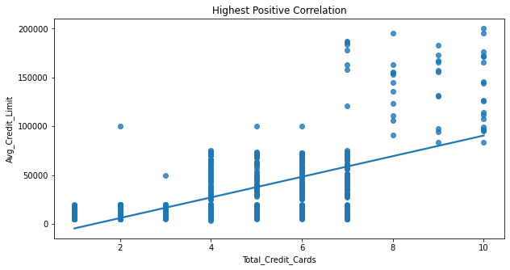

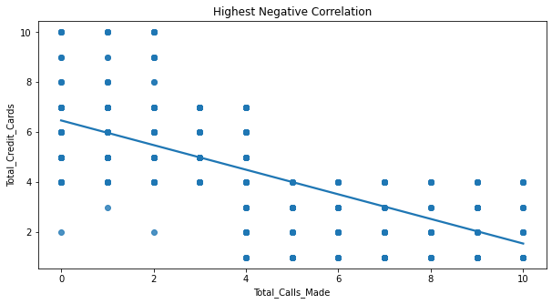

```python
#Let's get a visual representation of the most significant positive and negative correlations.
plt.figure(figsize=(10,5))
sns.regplot(data=df,x='Total_Credit_Cards', y='Avg_Credit_Limit',ci=None)
plt.title('Highest Positive Correlation')
plt.show()
print()

plt.figure(figsize=(10,5))
sns.regplot(data=df,x='Total_Calls_Made', y='Total_Credit_Cards',ci=None)
plt.title('Highest Negative Correlation')
plt.show()
```

[figure not shown]

```python
#Looking at the pairplot of the data for further analysis.
sns.pairplot(data=df, diag_kind='kde')
plt.show()
```

Judging by the amount of "waves" in the diagonals of the chart, it seems like 3 clusters would be a good place to start.

```python
print('*'*100)
```

DATA PREPROCESSING and KMEANS CLUSTERING (CENTROID)

```python
#Importing the necessary libraries for KMeans clustering.
from sklearn.cluster import KMeans
from scipy.stats import zscore
from sklearn.metrics import silhouette_score
from scipy.spatial.distance import cdist
```

```python
#Creating scaled data.
#Will not need to select specific columns as all are numeric and independent.
scaled_df = df.apply(zscore)
```

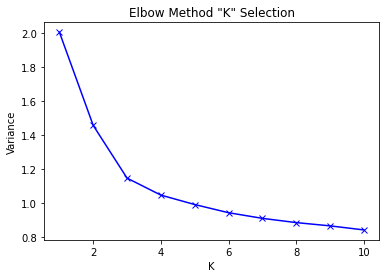

```python
#Creating an "Elbow Plot" to narrow down the optimal value of "K".
#Creating a list where the variances will be storred.
variances = []

#Using the pairplot it was found that roughly 3 clusters would be needed. However, general practice suggests that we try at least 10 clusters.
clusters = range(1,11)

#Setting up a "for" loop to test each cluster value.
for k in clusters:
  model = KMeans(n_clusters=k, random_state=1)
  model.fit(scaled_df)
  prediciton = model.predict(scaled_df)
  variances.append(sum(np.min(cdist(scaled_df,model.cluster_centers_,'euclidean'), axis=1)) / scaled_df.shape[0])

#Graphing the results of the search.
plt.plot(clusters, variances, 'bx-')
plt.xlabel('K')
plt.ylabel('Variance')
plt.title('Elbow Method "K" Selection')
```

From the above graph we can see that there is a sharp turn at "3". However, I will also try "4" as there can be an argument made for it as well and in general adding a value or two for comparison of silhouette scores is a good idea.

```
For n_clusters = 2, the silhouette score is 0.41842496663215445
For n_clusters = 3, the silhouette score is 0.5157182558881063
For n_clusters = 4, the silhouette score is 0.3556670619372605
For n_clusters = 5, the silhouette score is 0.2717470361089752
For n_clusters = 6, the silhouette score is 0.255906765297388
```

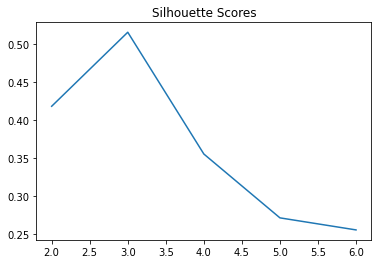

```python
#Checking silhouette scores for 3,4, and one value to the side of each for comparison.
#Chose 7 (technically 6) as top of range so that the graph comes out cleaner.
sil_scores = []
clusters2 = range(2,7)

for n in clusters2:
  model = KMeans(n_clusters=n, random_state=1)
  model.fit(scaled_df)
  prediction2 = model.predict(scaled_df)
  score = silhouette_score(scaled_df,prediction2)
  sil_scores.append(score)
  print('For n_clusters = {}, the silhouette score is {}'.format(n,score))

plt.plot(clusters2, sil_scores)
plt.title('Silhouette Scores')
```

"3" has the highest silhouette score by far and as such will be the value used.

```python
#Creating a KMeans cluster using 3 clusters.
final_model = KMeans(n_clusters=3, random_state=1)
final_model.fit(scaled_df)
pred3 = final_model.predict(scaled_df)

#Appending the prediction results into the scaled and original data sets.
scaled_df['KMeans'] = pred3
df['KMeans'] = pred3
```

```python
#Comparing the clusters by average values.
kmeans_clusters = df.groupby(['KMeans'])
kmeans_clusters.mean().style.highlight_max(color="green", axis=0).highlight_min(color="red", axis=0)
```

| KMeans | Avg_Credit_Limit | Total_Credit_Cards | Total_Visits_Bank | Total_Visits_Online | Total_Calls_Made |
| --- | --- | --- | --- | --- | --- |
| 0 | 12174.107143 | 2.410714 | 0.933036 | 3.553571 | 6.870536 |
| 1 | 33782.383420 | 5.515544 | 3.489637 | 0.981865 | 2.000000 |
| 2 | 141040.000000 | 8.740000 | 0.600000 | 10.900000 | 1.080000 |

Cluster "1" has the highest total bank visits in person and lowest amount of visits online.

Cluster "0" has the highest total calls made to the bank and lowest credit limit and total amount of credit cards.

Cluster "2" Has the highest credit limit, total amount of credit cards, and visits online, and the lowest amount of visits in person and calls made to the bank.

It seems that Cluster "0" contains customers who are unhappy with the bank and cluster "2" contains the customers who are happy with the bank.

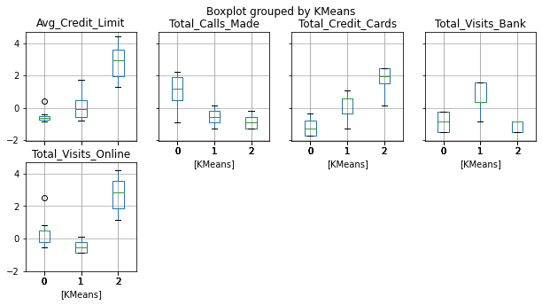

```python
#Getting a visual representation of cluster differences.
scaled_df.boxplot(by='KMeans', layout=(2,4), figsize=(10,5))
plt.show()
```

```python
print('*'*100)
```

HEIRARCHICAL CLUSTERING

```python
#Importing additional relevant libraries for heirarchical clustering.
from sklearn.cluster import AgglomerativeClustering
from scipy.spatial.distance import pdist
from scipy.cluster.hierarchy import cophenet, dendrogram, linkage
```

```python
#H-clustering with "single" linkage method.
z = linkage(scaled_df,method='single',metric='euclidean')
c, cophenetic_distances = cophenet(z,pdist(scaled_df))
```

```python
#Getting the cophenetic coefficient.
print(c)
```

```
0.8981791108157512
```

Very good score.

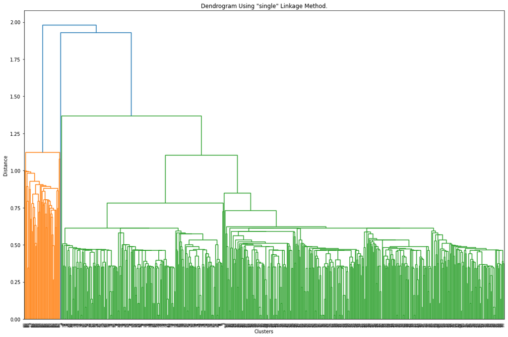

```python
plt.figure(figsize=(15,10))
dendrogram(z)
plt.title('Dendrogram Using "single" Linkage Method.')
plt.ylabel('Distance')
plt.xlabel('Clusters')
plt.tight_layout()
```

```python
#H-clustering with "complete" linkage method.
z = linkage(scaled_df,method='complete',metric='euclidean')
c, cophenetic_distances = cophenet(z,pdist(scaled_df))
```

```python
#Cophenetic coefficient.
print(c)
```

```
0.884420725860894
```

Also a good score but slightly wore than that of "single" linkage method.

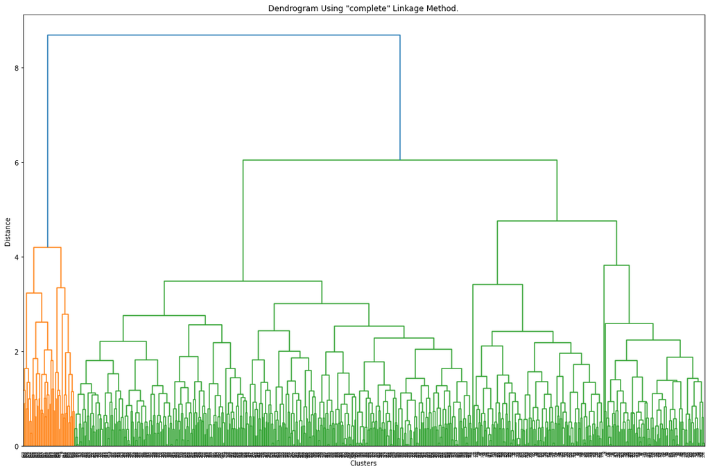

```python
plt.figure(figsize=(15,10))
dendrogram(z)
plt.title('Dendrogram Using "complete" Linkage Method.')
plt.ylabel('Distance')
plt.xlabel('Clusters')
plt.tight_layout()
```

```python
#H-clustering with "average" linkage method.
z = linkage(scaled_df,method='average',metric='euclidean')
c, cophenetic_distances = cophenet(z,pdist(scaled_df))
```

```python
#Cophenetic coefficient
print(c)
```

```
0.9102691112621796
```

The best result so far.

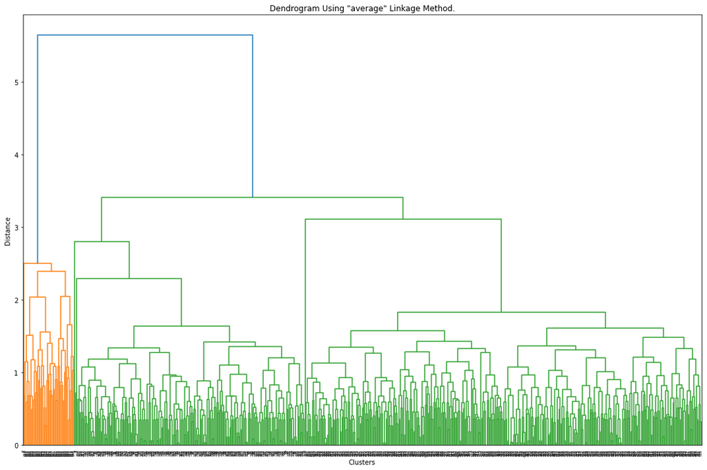

```python
plt.figure(figsize=(15,10))
dendrogram(z)
plt.title('Dendrogram Using "average" Linkage Method.')
plt.ylabel('Distance')
plt.xlabel('Clusters')
plt.tight_layout()
```

```python
#H-clustering with "centroid" linkage method.
z = linkage(scaled_df,method='centroid',metric='euclidean')
c, cophenetic_distances = cophenet(z,pdist(scaled_df))
```

```python
#Cophenetic coefficient
print(c)
```

```
0.906845257340526
```

Pretty much tied for first place.

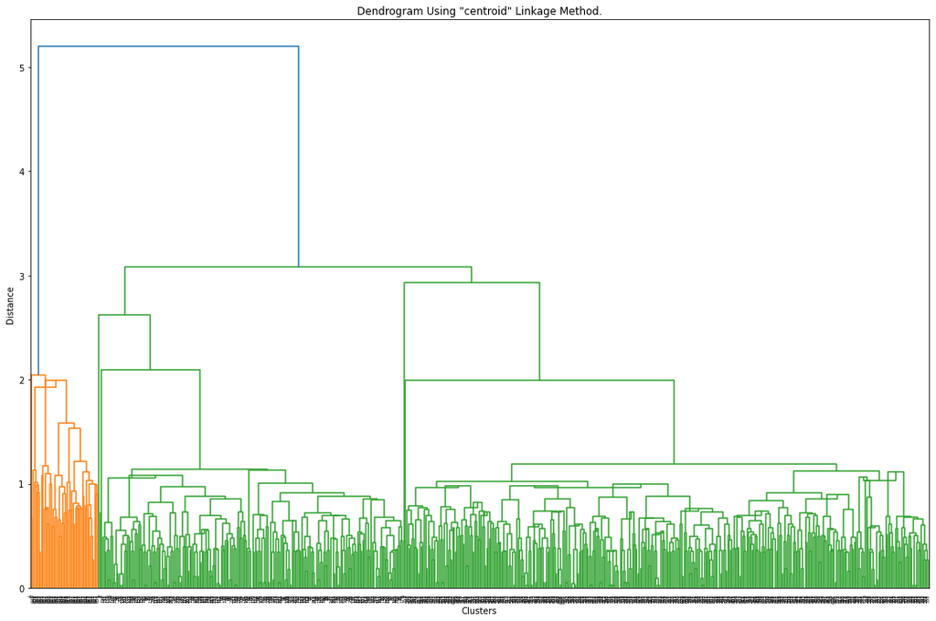

```python
plt.figure(figsize=(15,10))
dendrogram(z)
plt.title('Dendrogram Using "centroid" Linkage Method.')
plt.ylabel('Distance')
plt.xlabel('Clusters')
plt.tight_layout()
```

```python
#H-clustering with "ward" linkage method
z = linkage(scaled_df,method='ward',metric='euclidean')
c, cophenetic_distances = cophenet(z,pdist(scaled_df))
```

```python
#Cophenetic coefficient
print(c)
```

```
0.7566252666432097
```

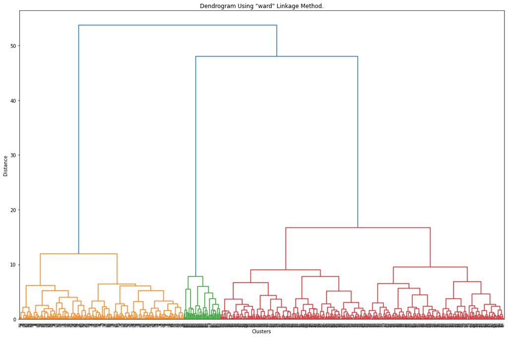

```python
plt.figure(figsize=(15,10))
dendrogram(z)
plt.title('Dendrogram Using "ward" Linkage Method.')
plt.ylabel('Distance')
plt.xlabel('Clusters')
plt.tight_layout()
```

The worst cophenetic coefficient result by far. However, the dendogram is the best choice at it has the "cleanest" separation of clusters. The others may have better scores but if you look at their dendrogram charts you will see that the variance changes rapidly which is represents a rapid increase in the amount of clusters.

In conclusion, the ward method seems to provide us with the best dendrogram as it has the most distinctive clustering. Among all of the rest the average method is the one that would come second as it has somewhat distinct clustering and the highest cophenetic score. However, as we will be using the ward method, based on it's dendrogram, we will be making a model with 3 clusters.

```python
#Creating an H-Clustering model using 3 clusters as determined above.
hmodel = AgglomerativeClustering(n_clusters=3, affinity='euclidean', linkage='ward')
hmodel.fit(scaled_df)
```

```
AgglomerativeClustering(n_clusters=3)
```

```python
#Adding H_Clustering results to both original and scaled dataframes.
df['H-Cluster'] = hmodel.labels_
scaled_df['H-Cluster'] = hmodel.labels_
```

```python
#Creating a customer profile
hcluster_profile = df.groupby(['H-Cluster']).mean()
hcluster_profile.style.highlight_max(color='green', axis=0).highlight_min(color='red', axis=0)
```

| H-Cluster | Avg_Credit_Limit | Total_Credit_Cards | Total_Visits_Bank | Total_Visits_Online | Total_Calls_Made | KMeans |
| --- | --- | --- | --- | --- | --- | --- |
| 0 | 33782.383420 | 5.515544 | 3.489637 | 0.981865 | 2.000000 | 1.000000 |
| 1 | 12174.107143 | 2.410714 | 0.933036 | 3.553571 | 6.870536 | 0.000000 |
| 2 | 141040.000000 | 8.740000 | 0.600000 | 10.900000 | 1.080000 | 2.000000 |

Cluster "0" contains customers who by far visit the bank the most in person and the least online.

Cluster "1" containts customers who by far make the most calls to the bank and have the least credit limit and credit cards with the bank.

Cluster "2" contains customers who by far the most credit limit and credit cards while having the lowest amount of in-person visits, slighly less than cluster "1", and the least calls made to the bank,slightly less than cluster "0".

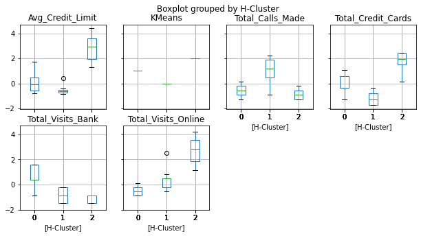

```python
#Getting a visual representation of cluster differences.
scaled_df.boxplot(by='H-Cluster', layout=(2,4), figsize=(10,5))
plt.show()
```

```python
print('*'*100)
```

Method Comparisons

Both in KMeans and H clustering cluster "2" represents customers who are happy with the bank's servies as shown by the high amount of credit cards and high credit limit. Cluster "1" in H-Clustering coresponds to cluster "0" in KMeans and, as a reminder, this catergory is full of customers who seem to be unhappy with the bank. Clusters "1" in KMeans and "0" in H-Cluster are customers who don't have any outstanding qualities in their relationship with the bank besides their tendency to visit the bank in person more than the other two and visit the bank less online, again, more than the other two.

```python
#Comparing the value counts of the two methods.
df_methods = df[['KMeans','H-Cluster']].copy()
print('KMeans gives us:\n',df_methods['KMeans'].value_counts())
print()
print('H_Cluster gives us:\n',df_methods['H-Cluster'].value_counts())
```

```
KMeans gives us:
 1    386
0    224
2     50
Name: KMeans, dtype: int64

H_Cluster gives us:
 0    386
1    224
2     50
Name: H-Cluster, dtype: int64
```

Both clustering methods gave the same amount of customers in each cluster.

```python
#Looking at the correlation between the results of KMeans and the results of Heirarchical clustering.
print('Unhappy customer correlation:',sum(df_methods[df_methods['KMeans'] == 0]['H-Cluster'].value_counts())/df_methods[df_methods['KMeans'] == 0].value_counts())
print('In-person customer correlation:',sum(df_methods[df_methods['KMeans'] == 1]['H-Cluster'].value_counts())/df_methods[df_methods['KMeans'] == 1].value_counts())
print('Happy customer correlation:',sum(df_methods[df_methods['KMeans'] == 2]['H-Cluster'].value_counts())/df_methods[df_methods['KMeans'] == 2].value_counts())
```

```
Unhappy customer correlation: KMeans  H-Cluster
0       1            1.0
dtype: float64
In-person customer correlation: KMeans  H-Cluster
1       0            1.0
dtype: float64
Happy customer correlation: KMeans  H-Cluster
2       2            1.0
dtype: float64
```

As shown by the results above, the KMeans clusters and the Heirarchical clusters are exactly the same as they contain the exact same data points in each cluster. This relationship is also shown in the "KMeans" scatterplot located in the boxplot graphs for H-Cluster results.

```python
print('*'*100)
```

BUSINESS INSIGHTS: Since both clustering methods gave the same results but different cluster labels, I will be using the labels from H-Clustering.

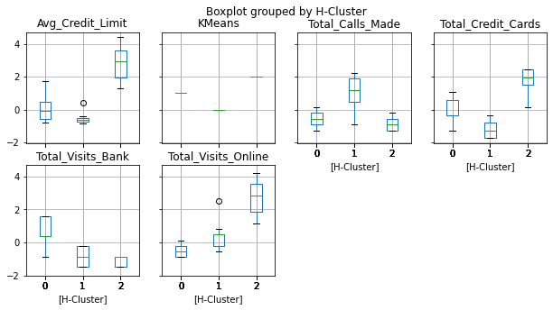

```
Amount of customers per cluster:
 0    386
1    224
2     50
Name: H-Cluster, dtype: int64
```

| H-Cluster | Avg_Credit_Limit | Total_Credit_Cards | Total_Visits_Bank | Total_Visits_Online | Total_Calls_Made | KMeans |
| --- | --- | --- | --- | --- | --- | --- |
| 0 | 33782.383420 | 5.515544 | 3.489637 | 0.981865 | 2.000000 | 1.000000 |
| 1 | 12174.107143 | 2.410714 | 0.933036 | 3.553571 | 6.870536 | 0.000000 |
| 2 | 141040.000000 | 8.740000 | 0.600000 | 10.900000 | 1.080000 | 2.000000 |

```python
#Copying the results from before.
scaled_df.boxplot(by='H-Cluster', layout=(2,4), figsize=(10,5))
plt.show()
print('\n')
print('\n')
print('Amount of customers per cluster:\n',df_methods['H-Cluster'].value_counts())
print()
hcluster_profile.style.highlight_max(color='green', axis=0).highlight_min(color='red', axis=0)
```

```python
#Reminder of the total amount of customers.
df.shape[0]
```

```
660
```

BUSINESS RECOMMENDATIONS:

Customers in label "1" are the ones most in need of quality customer serivce. They hold relatively few credit cards and have relatively low average credit limit while having the highest amount of calls made to the bank. This inidcates that they are very wary of entrusting their money to the bank due to the many issues they call about (no one calls when things are going well to congratulate the bank, they call when there is a problem). I would recommend focusing on placing extra effort to address the greivances of these customers. They make up (224/660) roughly a third of the customer base which means that if the bank can satisfy their complaints then it is potentially looking at a 34% increase in business, a very captivaing prospect.

Customers in label "2" are the ones that are satisfied with the banks services as represented by the low amount of phone calls made. They are the ones that account for most of the banks revenue as they have the highest amount of credit cards and highest average credit limit; indicating that they likely spend the most one way or another (either directly via credit card or though other means such as a loan). I recommend targeting this group of customers for promotions and upsells if applicable (also don't forget customer appreciation :). For example, emailing birthday wished, aniversaries, and "extra" good deals when savings options are given such as during a 4th of july or black friday/cyber monday sale). When that promotion is delivered, it is very important that it is delivered over the internet and not by mail or in-person. This is because customers in this group overwhelmingly visit the store online to such a degree that in-person visits are practically 0.

```python
print('*'*100)
```

Bonus PCA Analysis

```python
#Importing PCA library.
from sklearn.decomposition import PCA
```

```python
#Removing Cluster column
xscaled = scaled_df.drop(['KMeans','H-Cluster'], axis=1)
```

```python
#Creating PCA variable.
pca = PCA(random_state=1)
pca.fit(xscaled)
```

```
PCA(random_state=1)
```

```python
print(pca.explained_variance_ratio_)
```

```
[0.45736578 0.37426483 0.06401348 0.0555688  0.04878711]
```

This being as small of a data set as it is and not suffering from dimensionality issues makes doing PCA analysis frankly useless but at least it's interesting to know that no one variable is insignificant (less than 5% input. Technically the last variable is but if you round then it is not).

```python
print('*'*100)
```